# Simulation and Basic Inferential Data Analysis

Kent Mok

September 9, 2015

## Overview:

The purpose of this experiment is to investigate the exponential distribution in R, and to compare it with the Central Limit Theorem. The exponential distribution can be simulated in R with rexp(n, lambda) where lambda is the rate parameter and the mean of exponential distribution is 1/lambda. (Lambda will be set to 0.2 for this simulation.) This experiment will use 1000 simulations of the averages of 40 exponentials to investigate the distribution.

## Simulations:

Illustrate via simulation and associated explanatory text the properties of the distribution of the mean of 40 exponentials. You should

1. Show the sample mean and compare it to the theoretical mean of the distribution.
2. Show how variable the sample is (via variance) and compare it to the theoretical variance of the distribution.
3. Show that the distribution is approximately normal. Include English explanations of the simulations you ran, with the accompanying R code. Your explanations should make clear what the R code accomplishes.

## Sample Mean versus Theoretical Mean: Include figures with titles. In the figures, highlight the means you are comparing. Include text that explains the figures and what is shown on them, and provides appropriate numbers.

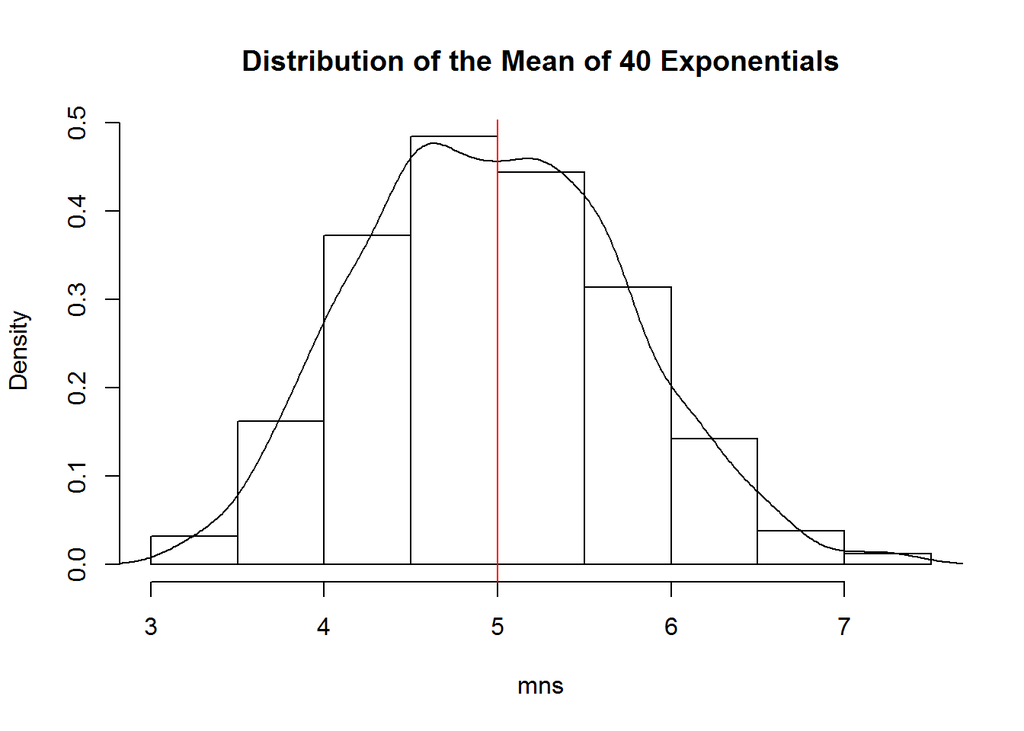

```r
set.seed(1234)

lambda = 0.2
numofsims = 1000
mns = NULL
for (i in 1:numofsims)
    mns = c(mns, mean(rexp(40, lambda)))

hist(mns, freq = FALSE, main = "Distribution of the Mean of 40 Exponentials")
lines(density(mns))
abline(v = 1/lambda, col = "red")
```

#### Figure 1 - Distribution of the Mean of 40 Exponentials

The above figure shows the distribution of one thousand simulations of the mean value for 40 exponentials.

The theoretical mean of the exponential distribution is given as $1/lambda$. $Lambda$ was set to 0.2, so the theoretical mean is $\beta = 1/\lambda = 1/0.2 = 5$. This is shown in Figure 1 as a red vertical line at $X = 5$.

It can be seen that the theoretical mean coincides with the sample mean, at least for a sample of 1000 simulations.

## Sample Variance versus Theoretical Variance: Include figures (output from R) with titles. Highlight the variances you are comparing. Include text that explains your understanding of the differences of the variances.

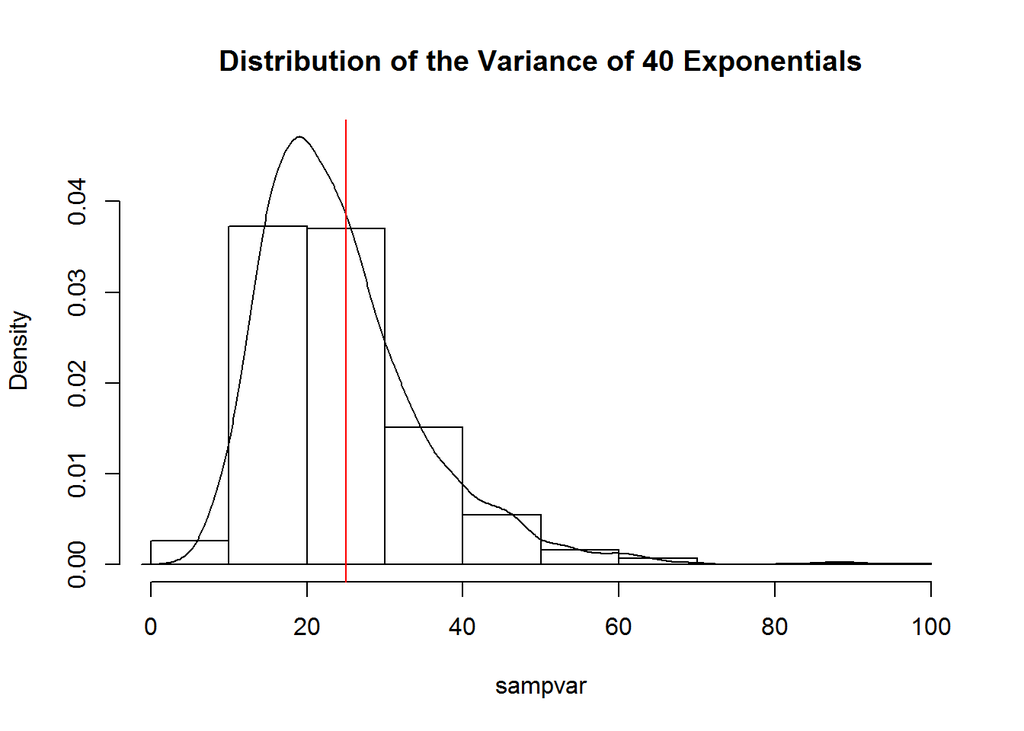

```r
set.seed(1234)

lambda = 0.2
numofsims = 1000
sampvar = NULL
for (i in 1:numofsims)
    sampvar = c(sampvar, var(rexp(40, lambda)))

ylimits = range(density(sampvar)$y)
hist(sampvar, freq = FALSE, main = "Distribution of the Variance of 40 Exponentials", ylim = ylimits)
lines(density(sampvar))
abline(v = 1/lambda^2, col = "red")
```

#### Figure 2 - Distribution of the Variance of 40 Exponentials

The above figure shows the distribution of one thousand simulations of the variance value for 40 exponentials.

The theoretical variance of the exponential distribution is given as $1/\lambda^2$. $\lambda$ was set to 0.2, so the theoretical variance is $1/\lambda^2 = 1/0.2^2 = 25$. This is shown in Figure 2 as a red vertical line at $X = 25$.

It can be seen that the theoretical variance coincides with the sample variance, at least for a sample of 1000 simulations.

## Distribution: Via figures and text, explain how one can tell the distribution is approximately normal.

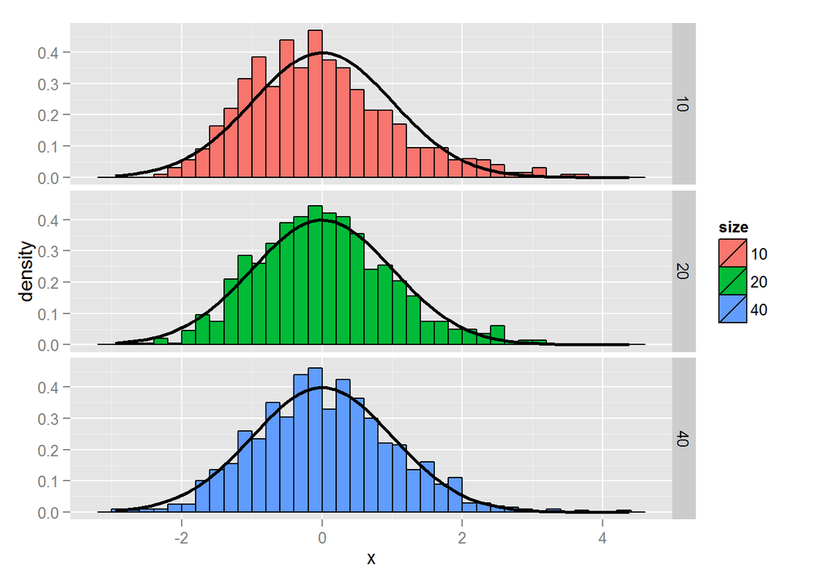

```r
library(ggplot2)
nosim <- 1000
cfunc <- function(x, n) sqrt(n) * (mean(x) - 5) / 5
dat <- data.frame(
  x = c(apply(matrix(rexp(nosim * 10, lambda), nosim), 1, cfunc, 10),
        apply(matrix(rexp(nosim * 20, lambda), nosim), 1, cfunc, 20),
        apply(matrix(rexp(nosim * 40, lambda), nosim), 1, cfunc, 40)
        ),
  size = factor(rep(c(10, 20, 40), rep(nosim, 3))))
g <- ggplot(dat, aes(x = x, fill = size)) + geom_histogram(colour = "black", binwidth = 0.2, aes(y = ..density..))
g <- g + stat_function(fun = dnorm, size = 1)
g + facet_grid(size ~ .)
```